[figure not shown]

# Credit EDA Case Study

*Authors: Anish Mahapatra, Karthik Premanand*

*Email IDs: anishmahapatra01@gmail.com, karthikprem26@gmail.com*

## *Group Case Study - 1*

The aim of this group case study is to apply EDA in a real business scenario. Besides an understanding of EDA, we shall also develop a basic understanding of **risk analytics in banking and financial services** and understand how data is used to minimise the risk of losing money while lending to customers.

### Problem Statement *Synthesis*

It is hard for the company to give loans to people with no credit history. We work in a consumer finance company which specializes in lending various types of loans to urban customers. We have to analyze patterns in the data. This will ensure that the applicants are capable of repaying the loan are not rejected.

When a loan application is recieved, there are two main risks associated with the bank's decision:

- If the applicant is likely to repay the loan, then not approving the loan results in a loss of business to the company
- If the applicant is not likely to repay the loan, i.e. he/she is likely to default, then approving the loan may lead to a financial loss for the company

The two scenarios that we are are concerned with are:

- The client with payment difficulties
- Paid on Time (named "All other cases")

The four decisions that can be taken by client/ company comprise of the below selection:

1. **Approved:** The company has approved the loan application
2. **Cancelled:** The client cancelled the loan application sometime during the approval. (Bad pricing or changed their mind)
3. **Refused:** The company has refused the loan application
4. **Unused Offer:** Loan has been cancelled by the client, but on different stage of progress

### Business Objectives

This case study aims to identify patterns which indicate if a client has difficulty paying their instalments which may be used for taking actions such as denying the loan, reducing the amount of loan, lending (to risky applicants) at a higher interest rate, etc. This will ensure that the consumers capable of repaying the loan are not rejected. Identification of such applicants using EDA is the aim of this case study.

### Datasets

1. **application_data.csv:** Contains all the information of the client at the time of application.The data is about whether a client has payment difficulties
2. **previous_application.csv:** Contains information about the client’s previous loan data. It contains the data whether the previous application had been Approved, Cancelled, Refused or Unused offer
3. **columns_description.csv:** Data dictionary which describes the meaning of the variables

### Results expected:

- Analysis in the form of a presentation
- NaN Treatment (with explanation)
- Outlier Treatment (with explanation)
- Handling data Imbalance (Imabalance Ratio)
- Explain the results of univariate, segmented univariate and bivariate analysis
- Find top 10 correlations for Client with payment difficulties and all other cases
- Include visualizations (Insights should explain why the variable is important for differentiating the clients with payment difficulties with all other cases)

#### Evalutation Rubrics:

- Identify and report the data quality issues (20%)
- Interpret variables correctly where required, mention them in the comments or text (20%)
- Address data-quality issues appropriately (10%)
- Data is in the right format (10%)
- String and date manipulation is done correctly (10%)
- The right problem is solved (50%)
- Univariate and *Segmented Univariate analysis* is done correctly (Identify 5 important driver variables) (50%)
- Business-driven, type-driven and data-driven metrics are created for the important variables and utilised for analysis (50%)
- Bivariate analysis is performed correctly and is able to identify the important combinations of driver variables (50%)
- The most useful insights are explained correctly in the comments (50%)
- The axes and important data points are labelled correctly (50%)
- The presentation has a clear structure, is not too long, and explains the most important results concisely (10%)
- The recommendations to solve the problems are realistic, actionable and coherent with the analysis (10%)
- If any assumptions are made, they are stated clearly (10%)
- Custom functions are used to perform repetitive tasks (10%)

```python
# Importing the required packages

import matplotlib.pyplot as plt
from numpy.random import randn
from numpy.random import seed
from numpy import percentile
from scipy import stats
import seaborn as sns
import pandas as pd
import numpy as np
%matplotlib inline
```

```python
# Removing the minimum display columns to 500
pd.set_option('display.max_columns', 500)
pd.set_option('display.max_rows', 500)
```

```python
# Importing the required csv from the folder:

applicationData = pd.read_csv('application_data.csv')
previousData = pd.read_csv('previous_application.csv')
```

```python
# Sense check of the application data

applicationData.head()
```

|  | SK_ID_CURR | TARGET | NAME_CONTRACT_TYPE | CODE_GENDER | FLAG_OWN_CAR | FLAG_OWN_REALTY | CNT_CHILDREN | AMT_INCOME_TOTAL | AMT_CREDIT | AMT_ANNUITY | AMT_GOODS_PRICE | NAME_TYPE_SUITE | NAME_INCOME_TYPE | NAME_EDUCATION_TYPE | NAME_FAMILY_STATUS | NAME_HOUSING_TYPE | REGION_POPULATION_RELATIVE | DAYS_BIRTH | DAYS_EMPLOYED | DAYS_REGISTRATION | DAYS_ID_PUBLISH | OWN_CAR_AGE | FLAG_MOBIL | FLAG_EMP_PHONE | FLAG_WORK_PHONE | FLAG_CONT_MOBILE | FLAG_PHONE | FLAG_EMAIL | OCCUPATION_TYPE | … |
| --- | --- | --- | --- | --- | --- | --- | --- | --- | --- | --- | --- | --- | --- | --- | --- | --- | --- | --- | --- | --- | --- | --- | --- | --- | --- | --- | --- | --- | --- | --- |
| 0 | 100002 | 1 | Cash loans | M | N | Y | 0 | 202500.0 | 406597.5 | 24700.5 | 351000.0 | Unaccompanied | Working | Secondary / secondary special | Single / not married | House / apartment | 0.018801 | -9461 | -637 | -3648.0 | -2120 | NaN | 1 | 1 | 0 | 1 | 1 | 0 | Laborers | … |
| 1 | 100003 | 0 | Cash loans | F | N | N | 0 | 270000.0 | 1293502.5 | 35698.5 | 1129500.0 | Family | State servant | Higher education | Married | House / apartment | 0.003541 | -16765 | -1188 | -1186.0 | -291 | NaN | 1 | 1 | 0 | 1 | 1 | 0 | Core staff | … |
| 2 | 100004 | 0 | Revolving loans | M | Y | Y | 0 | 67500.0 | 135000.0 | 6750.0 | 135000.0 | Unaccompanied | Working | Secondary / secondary special | Single / not married | House / apartment | 0.010032 | -19046 | -225 | -4260.0 | -2531 | 26.0 | 1 | 1 | 1 | 1 | 1 | 0 | Laborers | … |
| 3 | 100006 | 0 | Cash loans | F | N | Y | 0 | 135000.0 | 312682.5 | 29686.5 | 297000.0 | Unaccompanied | Working | Secondary / secondary special | Civil marriage | House / apartment | 0.008019 | -19005 | -3039 | -9833.0 | -2437 | NaN | 1 | 1 | 0 | 1 | 0 | 0 | Laborers | … |
| 4 | 100007 | 0 | Cash loans | M | N | Y | 0 | 121500.0 | 513000.0 | 21865.5 | 513000.0 | Unaccompanied | Working | Secondary / secondary special | Single / not married | House / apartment | 0.028663 | -19932 | -3038 | -4311.0 | -3458 | NaN | 1 | 1 | 0 | 1 | 0 | 0 | Core staff | … |

```python
# Sense check of the previous data
previousData.head()
```

|  | SK_ID_PREV | SK_ID_CURR | NAME_CONTRACT_TYPE | AMT_ANNUITY | AMT_APPLICATION | AMT_CREDIT | AMT_DOWN_PAYMENT | AMT_GOODS_PRICE | WEEKDAY_APPR_PROCESS_START | HOUR_APPR_PROCESS_START | FLAG_LAST_APPL_PER_CONTRACT | NFLAG_LAST_APPL_IN_DAY | RATE_DOWN_PAYMENT | RATE_INTEREST_PRIMARY | RATE_INTEREST_PRIVILEGED | NAME_CASH_LOAN_PURPOSE | NAME_CONTRACT_STATUS | DAYS_DECISION | NAME_PAYMENT_TYPE | CODE_REJECT_REASON | NAME_TYPE_SUITE | NAME_CLIENT_TYPE | NAME_GOODS_CATEGORY | NAME_PORTFOLIO | NAME_PRODUCT_TYPE | CHANNEL_TYPE | SELLERPLACE_AREA | NAME_SELLER_INDUSTRY | CNT_PAYMENT | … |
| --- | --- | --- | --- | --- | --- | --- | --- | --- | --- | --- | --- | --- | --- | --- | --- | --- | --- | --- | --- | --- | --- | --- | --- | --- | --- | --- | --- | --- | --- | --- |
| 0 | 2030495 | 271877 | Consumer loans | 1730.430 | 17145.0 | 17145.0 | 0.0 | 17145.0 | SATURDAY | 15 | Y | 1 | 0.0 | 0.182832 | 0.867336 | XAP | Approved | -73 | Cash through the bank | XAP | NaN | Repeater | Mobile | POS | XNA | Country-wide | 35 | Connectivity | 12.0 | … |
| 1 | 2802425 | 108129 | Cash loans | 25188.615 | 607500.0 | 679671.0 | NaN | 607500.0 | THURSDAY | 11 | Y | 1 | NaN | NaN | NaN | XNA | Approved | -164 | XNA | XAP | Unaccompanied | Repeater | XNA | Cash | x-sell | Contact center | -1 | XNA | 36.0 | … |
| 2 | 2523466 | 122040 | Cash loans | 15060.735 | 112500.0 | 136444.5 | NaN | 112500.0 | TUESDAY | 11 | Y | 1 | NaN | NaN | NaN | XNA | Approved | -301 | Cash through the bank | XAP | Spouse, partner | Repeater | XNA | Cash | x-sell | Credit and cash offices | -1 | XNA | 12.0 | … |
| 3 | 2819243 | 176158 | Cash loans | 47041.335 | 450000.0 | 470790.0 | NaN | 450000.0 | MONDAY | 7 | Y | 1 | NaN | NaN | NaN | XNA | Approved | -512 | Cash through the bank | XAP | NaN | Repeater | XNA | Cash | x-sell | Credit and cash offices | -1 | XNA | 12.0 | … |
| 4 | 1784265 | 202054 | Cash loans | 31924.395 | 337500.0 | 404055.0 | NaN | 337500.0 | THURSDAY | 9 | Y | 1 | NaN | NaN | NaN | Repairs | Refused | -781 | Cash through the bank | HC | NaN | Repeater | XNA | Cash | walk-in | Credit and cash offices | -1 | XNA | 24.0 | … |

#### Approach

- Look at the head(), info(), shape, dtype of the data

##### For application_train.csv file:

- Check the % of **missing values** in each row and remove the rows that have a high percentage of missing values >(10-13%)
- Show how to impute **impute** the column, check if the column can be imputed:
  - categorical --> mode, continuous --> mean, median.
- Check and change the **data types** if required. Compare with data description.
- For numerical columns (say 3 to 5 columns), do **outlier treatment** (plot box plot and observe spread of the data)
- **Bin** the continuous variables into categories (at least 2 columns) - like high, medium, low etc
- Check the % imbalance for the target variable. No balancing technique.
- Divide the data into two sets with target = 1 and target = 0
- Perform univariate on the numerical columns. Explain the plots
- Find top 10 correlated variables for df1 and df0
- Check if there are common top correlated variables for df1 and df0. Comment why or why it is not happening
- Perform bivariate analysis on the continuous variables

#### For previous_application.csv file:

- Look at how you can merge previous application with application_train.csv file
- Do no worry about missing values
- Perform univariate and bivariate analysis

## EDA of application_train

### Sense Check of the data

```python
# Checking the top 5 rows and headers of the data
applicationData.head()
```

|  | SK_ID_CURR | TARGET | NAME_CONTRACT_TYPE | CODE_GENDER | FLAG_OWN_CAR | FLAG_OWN_REALTY | CNT_CHILDREN | AMT_INCOME_TOTAL | AMT_CREDIT | AMT_ANNUITY | AMT_GOODS_PRICE | NAME_TYPE_SUITE | NAME_INCOME_TYPE | NAME_EDUCATION_TYPE | NAME_FAMILY_STATUS | NAME_HOUSING_TYPE | REGION_POPULATION_RELATIVE | DAYS_BIRTH | DAYS_EMPLOYED | DAYS_REGISTRATION | DAYS_ID_PUBLISH | OWN_CAR_AGE | FLAG_MOBIL | FLAG_EMP_PHONE | FLAG_WORK_PHONE | FLAG_CONT_MOBILE | FLAG_PHONE | FLAG_EMAIL | OCCUPATION_TYPE | … |
| --- | --- | --- | --- | --- | --- | --- | --- | --- | --- | --- | --- | --- | --- | --- | --- | --- | --- | --- | --- | --- | --- | --- | --- | --- | --- | --- | --- | --- | --- | --- |
| 0 | 100002 | 1 | Cash loans | M | N | Y | 0 | 202500.0 | 406597.5 | 24700.5 | 351000.0 | Unaccompanied | Working | Secondary / secondary special | Single / not married | House / apartment | 0.018801 | -9461 | -637 | -3648.0 | -2120 | NaN | 1 | 1 | 0 | 1 | 1 | 0 | Laborers | … |
| 1 | 100003 | 0 | Cash loans | F | N | N | 0 | 270000.0 | 1293502.5 | 35698.5 | 1129500.0 | Family | State servant | Higher education | Married | House / apartment | 0.003541 | -16765 | -1188 | -1186.0 | -291 | NaN | 1 | 1 | 0 | 1 | 1 | 0 | Core staff | … |
| 2 | 100004 | 0 | Revolving loans | M | Y | Y | 0 | 67500.0 | 135000.0 | 6750.0 | 135000.0 | Unaccompanied | Working | Secondary / secondary special | Single / not married | House / apartment | 0.010032 | -19046 | -225 | -4260.0 | -2531 | 26.0 | 1 | 1 | 1 | 1 | 1 | 0 | Laborers | … |
| 3 | 100006 | 0 | Cash loans | F | N | Y | 0 | 135000.0 | 312682.5 | 29686.5 | 297000.0 | Unaccompanied | Working | Secondary / secondary special | Civil marriage | House / apartment | 0.008019 | -19005 | -3039 | -9833.0 | -2437 | NaN | 1 | 1 | 0 | 1 | 0 | 0 | Laborers | … |
| 4 | 100007 | 0 | Cash loans | M | N | Y | 0 | 121500.0 | 513000.0 | 21865.5 | 513000.0 | Unaccompanied | Working | Secondary / secondary special | Single / not married | House / apartment | 0.028663 | -19932 | -3038 | -4311.0 | -3458 | NaN | 1 | 1 | 0 | 1 | 0 | 0 | Core staff | … |

```python
# Looking at the type fo the data frame, data types and the number of rows
applicationData.info()
```

```
<class 'pandas.core.frame.DataFrame'>
RangeIndex: 307511 entries, 0 to 307510
Columns: 122 entries, SK_ID_CURR to AMT_REQ_CREDIT_BUREAU_YEAR
dtypes: float64(65), int64(41), object(16)
memory usage: 286.2+ MB
```

```python
# Checking the number of rows and columns present in the data
applicationData.shape
```

```
(307511, 122)
```

```python
# Looking at the data types of the data
applicationData.dtypes.head()
```

```
SK_ID_CURR             int64
TARGET                 int64
NAME_CONTRACT_TYPE    object
CODE_GENDER           object
FLAG_OWN_CAR          object
dtype: object
```

```python
# Making a copy of the application in dataframe df (checkpoint!)
df = applicationData.copy(deep=False)
```

```python
# Calculating the percent of missing values in the dataframe
percentMissing = (df.isnull().sum() / len(df)) * 100

# Making a dataframe with the missing values % and columns into a dataframe (on account of large number of rows)
missingValuesDf = pd.DataFrame({'columnName': df.columns,
                                 'percentMissing': percentMissing})
```

```python
# Viewing the dataframe to ensure that the values have been populated correctly
missingValuesDf.head()
```

|  | columnName | percentMissing |
| --- | --- | --- |
| SK_ID_CURR | SK_ID_CURR | 0.0 |
| TARGET | TARGET | 0.0 |
| NAME_CONTRACT_TYPE | NAME_CONTRACT_TYPE | 0.0 |
| CODE_GENDER | CODE_GENDER | 0.0 |
| FLAG_OWN_CAR | FLAG_OWN_CAR | 0.0 |

```python
# Viewing the columns that have more than 10% of missing data
missingValuesDf.loc[missingValuesDf['percentMissing'] > 10].head()
```

|  | columnName | percentMissing |
| --- | --- | --- |
| OWN_CAR_AGE | OWN_CAR_AGE | 65.990810 |
| OCCUPATION_TYPE | OCCUPATION_TYPE | 31.345545 |
| EXT_SOURCE_1 | EXT_SOURCE_1 | 56.381073 |
| EXT_SOURCE_3 | EXT_SOURCE_3 | 19.825307 |
| APARTMENTS_AVG | APARTMENTS_AVG | 50.749729 |

```python
missingValuesDf.loc[missingValuesDf['percentMissing'] > 10].shape
```

```
(57, 2)
```

Here, we notice that there are 57 column of the original 122 columns that have more than 10% missing values.

So, we shall have 65 columns in the modified dataset

```python
# Obtaining the columns with more than 10% missing data
columnsWithMissingValues = missingValuesDf.loc[missingValuesDf['percentMissing'] > 10]
missingColumns = columnsWithMissingValues['columnName'].reset_index(drop=True).tolist()
```

```python
# Droppping the columns with more than 10% missing values from the original dataset
df.drop(missingColumns, axis=1, inplace=True)
```

```python
# Looking at the shape of the modified data
df.shape
```

```
(307511, 65)
```

```python
# Viewing the head of the data
df.head()
```

|  | SK_ID_CURR | TARGET | NAME_CONTRACT_TYPE | CODE_GENDER | FLAG_OWN_CAR | FLAG_OWN_REALTY | CNT_CHILDREN | AMT_INCOME_TOTAL | AMT_CREDIT | AMT_ANNUITY | AMT_GOODS_PRICE | NAME_TYPE_SUITE | NAME_INCOME_TYPE | NAME_EDUCATION_TYPE | NAME_FAMILY_STATUS | NAME_HOUSING_TYPE | REGION_POPULATION_RELATIVE | DAYS_BIRTH | DAYS_EMPLOYED | DAYS_REGISTRATION | DAYS_ID_PUBLISH | FLAG_MOBIL | FLAG_EMP_PHONE | FLAG_WORK_PHONE | FLAG_CONT_MOBILE | FLAG_PHONE | FLAG_EMAIL | CNT_FAM_MEMBERS | REGION_RATING_CLIENT | … |
| --- | --- | --- | --- | --- | --- | --- | --- | --- | --- | --- | --- | --- | --- | --- | --- | --- | --- | --- | --- | --- | --- | --- | --- | --- | --- | --- | --- | --- | --- | --- |
| 0 | 100002 | 1 | Cash loans | M | N | Y | 0 | 202500.0 | 406597.5 | 24700.5 | 351000.0 | Unaccompanied | Working | Secondary / secondary special | Single / not married | House / apartment | 0.018801 | -9461 | -637 | -3648.0 | -2120 | 1 | 1 | 0 | 1 | 1 | 0 | 1.0 | 2 | … |
| 1 | 100003 | 0 | Cash loans | F | N | N | 0 | 270000.0 | 1293502.5 | 35698.5 | 1129500.0 | Family | State servant | Higher education | Married | House / apartment | 0.003541 | -16765 | -1188 | -1186.0 | -291 | 1 | 1 | 0 | 1 | 1 | 0 | 2.0 | 1 | … |
| 2 | 100004 | 0 | Revolving loans | M | Y | Y | 0 | 67500.0 | 135000.0 | 6750.0 | 135000.0 | Unaccompanied | Working | Secondary / secondary special | Single / not married | House / apartment | 0.010032 | -19046 | -225 | -4260.0 | -2531 | 1 | 1 | 1 | 1 | 1 | 0 | 1.0 | 2 | … |
| 3 | 100006 | 0 | Cash loans | F | N | Y | 0 | 135000.0 | 312682.5 | 29686.5 | 297000.0 | Unaccompanied | Working | Secondary / secondary special | Civil marriage | House / apartment | 0.008019 | -19005 | -3039 | -9833.0 | -2437 | 1 | 1 | 0 | 1 | 0 | 0 | 2.0 | 2 | … |
| 4 | 100007 | 0 | Cash loans | M | N | Y | 0 | 121500.0 | 513000.0 | 21865.5 | 513000.0 | Unaccompanied | Working | Secondary / secondary special | Single / not married | House / apartment | 0.028663 | -19932 | -3038 | -4311.0 | -3458 | 1 | 1 | 0 | 1 | 0 | 0 | 1.0 | 2 | … |

### Imputing the columns

Let us now discuss the approach to impute the rest of the columns with missing values. *(as mentioned in the video by mentor Sumit Shukhla)*

The methods generally employed to impute values is two-fold:

1. **Continuous Variables:** Can be imputed with *mean, median or mode* depending on the distribution of the column
2. **Categorical variables:** Imputed with the *mode* of the column

```python
# Calculating the percent of missing values in the dataframe
percentMissing = (df.isnull().sum() / len(df)) * 100

# Making a dataframe with the missing values % and columns into a dataframe (on account of large number of rows)
missingValuesDf = pd.DataFrame({'columnName': df.columns,
                                 'percentMissing': percentMissing})
```

```python
# Selecting the columns that have missing values
colsLessThan10Percent = missingValuesDf.loc[missingValuesDf['percentMissing'] > 0]
```

As we have removed the columns that have more than 10% of missing values, we have 10 columns that can de imputed. Let us now observe these columns.

```python
# Converting the columns to a list so that it can be used to subset the data directly
# (as imputation is for representational purposes)
colsLessThan10Percent = colsLessThan10Percent.columnName.tolist()
colsLessThan10Percent
```

```
['AMT_ANNUITY',
 'AMT_GOODS_PRICE',
 'NAME_TYPE_SUITE',
 'CNT_FAM_MEMBERS',
 'EXT_SOURCE_2',
 'OBS_30_CNT_SOCIAL_CIRCLE',
 'DEF_30_CNT_SOCIAL_CIRCLE',
 'OBS_60_CNT_SOCIAL_CIRCLE',
 'DEF_60_CNT_SOCIAL_CIRCLE',
 'DAYS_LAST_PHONE_CHANGE']
```

```python
# Subsetting columns with missing values
dfImpute = df[['AMT_ANNUITY', 'AMT_GOODS_PRICE', 'NAME_TYPE_SUITE', 'CNT_FAM_MEMBERS', 'EXT_SOURCE_2', 'OBS_30_CNT_SOCIAL_CIRCLE',
 'DEF_30_CNT_SOCIAL_CIRCLE', 'OBS_60_CNT_SOCIAL_CIRCLE', 'DEF_60_CNT_SOCIAL_CIRCLE', 'DAYS_LAST_PHONE_CHANGE']]
```

```python
# Viewing the data types of imputable columns
dfImpute.dtypes
```

```
AMT_ANNUITY                 float64
AMT_GOODS_PRICE             float64
NAME_TYPE_SUITE              object
CNT_FAM_MEMBERS             float64
EXT_SOURCE_2                float64
OBS_30_CNT_SOCIAL_CIRCLE    float64
DEF_30_CNT_SOCIAL_CIRCLE    float64
OBS_60_CNT_SOCIAL_CIRCLE    float64
DEF_60_CNT_SOCIAL_CIRCLE    float64
DAYS_LAST_PHONE_CHANGE      float64
dtype: object
```

```python
# Viewing the the head of imputable columns
dfImpute.head()
```

|  | AMT_ANNUITY | AMT_GOODS_PRICE | NAME_TYPE_SUITE | CNT_FAM_MEMBERS | EXT_SOURCE_2 | OBS_30_CNT_SOCIAL_CIRCLE | DEF_30_CNT_SOCIAL_CIRCLE | OBS_60_CNT_SOCIAL_CIRCLE | DEF_60_CNT_SOCIAL_CIRCLE | DAYS_LAST_PHONE_CHANGE |
| --- | --- | --- | --- | --- | --- | --- | --- | --- | --- | --- |
| 0 | 24700.5 | 351000.0 | Unaccompanied | 1.0 | 0.262949 | 2.0 | 2.0 | 2.0 | 2.0 | -1134.0 |
| 1 | 35698.5 | 1129500.0 | Family | 2.0 | 0.622246 | 1.0 | 0.0 | 1.0 | 0.0 | -828.0 |
| 2 | 6750.0 | 135000.0 | Unaccompanied | 1.0 | 0.555912 | 0.0 | 0.0 | 0.0 | 0.0 | -815.0 |
| 3 | 29686.5 | 297000.0 | Unaccompanied | 2.0 | 0.650442 | 2.0 | 0.0 | 2.0 | 0.0 | -617.0 |
| 4 | 21865.5 | 513000.0 | Unaccompanied | 1.0 | 0.322738 | 0.0 | 0.0 | 0.0 | 0.0 | -1106.0 |

Let us analyze the description of the columns:

- AMT_ANNUITY - Loan annuity (median)
- AMT_GOODS_PRICE - For consumer loans it is the price of the goods for which the loan is given (median)
- NAME_TYPE_SUITE - Who was accompanying client when he was applying for the loan (mode)
- CNT_FAM_MEMBERS - How many family members does client have (median)
- EXT_SOURCE_2 - Normalized score from external data source (median)
- OBS_30_CNT_SOCIAL_CIRCLE - How many observation of client's social surroundings with observable 30 DPD default (median)
- DEF_30_CNT_SOCIAL_CIRCLE - How many observation of client's social surroundings defaulted on 30 DPD (median)
- OBS_60_CNT_SOCIAL_CIRCLE - How many observation of client's social surroundings with observable 60 DPD default (median)
- DEF_60_CNT_SOCIAL_CIRCLE - How many observation of client's social surroundings defaulted on 60 DPD (median)
- DAYS_LAST_PHONE_CHANGE - How many days before application did client change phone (median)

The above imputation methods have been decided by observing the values of the table, the business logic (definitions from Google) and general sense of the data.

where *DPD - days past due

```python
# Selecting only the numeric columns to impute
numerics = ['int16', 'int32', 'int64', 'float16', 'float32', 'float64']

dfImpute_num = dfImpute.select_dtypes(include=numerics)
```

```python
# Imputing the numeric values with median values
dfImpute_num.fillna(dfImpute_num.median(), inplace=True)
```

```python
# Checking to see if the NaN values have been imputed
dfImpute_num.isna().sum()
```

```
AMT_ANNUITY                 0
AMT_GOODS_PRICE             0
CNT_FAM_MEMBERS             0
EXT_SOURCE_2                0
OBS_30_CNT_SOCIAL_CIRCLE    0
DEF_30_CNT_SOCIAL_CIRCLE    0
OBS_60_CNT_SOCIAL_CIRCLE    0
DEF_60_CNT_SOCIAL_CIRCLE    0
DAYS_LAST_PHONE_CHANGE      0
dtype: int64
```

```python
# Selecting the categorical values from the dataframe
dfImpute_cat = dfImpute.select_dtypes(include='object')
```

```python
# Substituting the categorical column with mode of the column
dfImpute_cat = dfImpute_cat.fillna(dfImpute_cat.mode().iloc[0])
```

```python
# Checking to see if we have imputed the values
dfImpute_cat.isna().sum()
```

```
NAME_TYPE_SUITE    0
dtype: int64
```

Since most of the functions used below has built in methods to handle n.a values internally, we will run the rest of the analysis on the original rather than the imputed dataset. Nontheless the methods of imputation is already done above and datasets can easily be substituted in case imputed values are preferred.

### Checking the data types

```python
df.shape
```

```
(307511, 65)
```

```python
# Viewing the data
df.head()
```

|  | SK_ID_CURR | TARGET | NAME_CONTRACT_TYPE | CODE_GENDER | FLAG_OWN_CAR | FLAG_OWN_REALTY | CNT_CHILDREN | AMT_INCOME_TOTAL | AMT_CREDIT | AMT_ANNUITY | AMT_GOODS_PRICE | NAME_TYPE_SUITE | NAME_INCOME_TYPE | NAME_EDUCATION_TYPE | NAME_FAMILY_STATUS | NAME_HOUSING_TYPE | REGION_POPULATION_RELATIVE | DAYS_BIRTH | DAYS_EMPLOYED | DAYS_REGISTRATION | DAYS_ID_PUBLISH | FLAG_MOBIL | FLAG_EMP_PHONE | FLAG_WORK_PHONE | FLAG_CONT_MOBILE | FLAG_PHONE | FLAG_EMAIL | CNT_FAM_MEMBERS | REGION_RATING_CLIENT | … |
| --- | --- | --- | --- | --- | --- | --- | --- | --- | --- | --- | --- | --- | --- | --- | --- | --- | --- | --- | --- | --- | --- | --- | --- | --- | --- | --- | --- | --- | --- | --- |
| 0 | 100002 | 1 | Cash loans | M | N | Y | 0 | 202500.0 | 406597.5 | 24700.5 | 351000.0 | Unaccompanied | Working | Secondary / secondary special | Single / not married | House / apartment | 0.018801 | -9461 | -637 | -3648.0 | -2120 | 1 | 1 | 0 | 1 | 1 | 0 | 1.0 | 2 | … |
| 1 | 100003 | 0 | Cash loans | F | N | N | 0 | 270000.0 | 1293502.5 | 35698.5 | 1129500.0 | Family | State servant | Higher education | Married | House / apartment | 0.003541 | -16765 | -1188 | -1186.0 | -291 | 1 | 1 | 0 | 1 | 1 | 0 | 2.0 | 1 | … |
| 2 | 100004 | 0 | Revolving loans | M | Y | Y | 0 | 67500.0 | 135000.0 | 6750.0 | 135000.0 | Unaccompanied | Working | Secondary / secondary special | Single / not married | House / apartment | 0.010032 | -19046 | -225 | -4260.0 | -2531 | 1 | 1 | 1 | 1 | 1 | 0 | 1.0 | 2 | … |
| 3 | 100006 | 0 | Cash loans | F | N | Y | 0 | 135000.0 | 312682.5 | 29686.5 | 297000.0 | Unaccompanied | Working | Secondary / secondary special | Civil marriage | House / apartment | 0.008019 | -19005 | -3039 | -9833.0 | -2437 | 1 | 1 | 0 | 1 | 0 | 0 | 2.0 | 2 | … |
| 4 | 100007 | 0 | Cash loans | M | N | Y | 0 | 121500.0 | 513000.0 | 21865.5 | 513000.0 | Unaccompanied | Working | Secondary / secondary special | Single / not married | House / apartment | 0.028663 | -19932 | -3038 | -4311.0 | -3458 | 1 | 1 | 0 | 1 | 0 | 0 | 1.0 | 2 | … |

```python
# Checking the datatypes
df.dtypes
```

```
SK_ID_CURR                       int64
TARGET                           int64
NAME_CONTRACT_TYPE              object
CODE_GENDER                     object
FLAG_OWN_CAR                    object
FLAG_OWN_REALTY                 object
CNT_CHILDREN                     int64
AMT_INCOME_TOTAL               float64
AMT_CREDIT                     float64
AMT_ANNUITY                    float64
AMT_GOODS_PRICE                float64
NAME_TYPE_SUITE                 object
NAME_INCOME_TYPE                object
NAME_EDUCATION_TYPE             object
NAME_FAMILY_STATUS              object
NAME_HOUSING_TYPE               object
REGION_POPULATION_RELATIVE     float64
DAYS_BIRTH                       int64
DAYS_EMPLOYED                    int64
DAYS_REGISTRATION              float64
DAYS_ID_PUBLISH                  int64
FLAG_MOBIL                       int64
FLAG_EMP_PHONE                   int64
FLAG_WORK_PHONE                  int64
FLAG_CONT_MOBILE                 int64
FLAG_PHONE                       int64
FLAG_EMAIL                       int64
CNT_FAM_MEMBERS                float64
REGION_RATING_CLIENT             int64
REGION_RATING_CLIENT_W_CITY      int64
WEEKDAY_APPR_PROCESS_START      object
HOUR_APPR_PROCESS_START          int64
REG_REGION_NOT_LIVE_REGION       int64
REG_REGION_NOT_WORK_REGION       int64
LIVE_REGION_NOT_WORK_REGION      int64
REG_CITY_NOT_LIVE_CITY           int64
REG_CITY_NOT_WORK_CITY           int64
LIVE_CITY_NOT_WORK_CITY          int64
ORGANIZATION_TYPE               object
EXT_SOURCE_2                   float64
```

[output cut: 11 more lines]

```
FLAG_DOCUMENT_8                  int64
FLAG_DOCUMENT_9                  int64
FLAG_DOCUMENT_10                 int64
FLAG_DOCUMENT_11                 int64
FLAG_DOCUMENT_12                 int64
FLAG_DOCUMENT_13                 int64
FLAG_DOCUMENT_14                 int64
FLAG_DOCUMENT_15                 int64
FLAG_DOCUMENT_16                 int64
FLAG_DOCUMENT_17                 int64
FLAG_DOCUMENT_18                 int64
FLAG_DOCUMENT_19                 int64
FLAG_DOCUMENT_20                 int64
FLAG_DOCUMENT_21                 int64
dtype: object
```

### Outlier Treatment Analysis

```python
# Defining a function to make boxplots for a specified dataframe
def plotBoxPlot(df, colName):
    '''
    This function is used to set the stype of the box plot, name the graph and plot the box plot for the specified column

    Inputs:
    @df (dataframe) - The dataframe for which boxplots are to be plotted
    @colName (string) - The numeric column for which box plot is to be plotted

    Output:
    Titles box plot of specified colName
    '''
    sns.set(style="whitegrid")
    plt.figure(figsize=(20,5))
    plt.title(colName)
    sns.boxplot(x=df[colName])

    #fig = px.box(df, x=colName)#, y="total_bill")
    #fig.show()
```

**Note:** The Boxplots below have been plotted with the standard whiskers of 1.5 x (IQR)

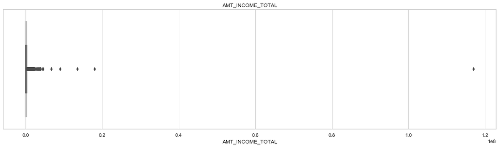

```python
# Plotting Box Plot for the below defined numeric column
plotBoxPlot(df, "AMT_INCOME_TOTAL")
```

**Findings:** From the above plot of the income of the client above, we notice that quite a few people earn more than the average.

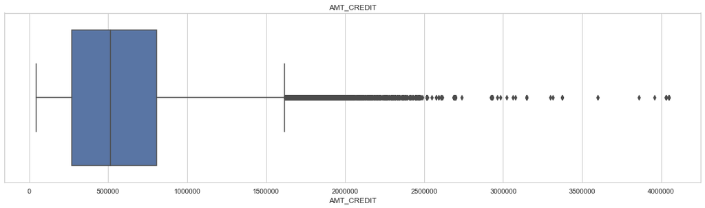

```python
# Plotting Box Plot for the below defined numeric column
plotBoxPlot(df, "AMT_CREDIT")
```

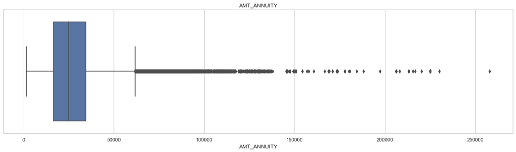

```python
# Plotting Box Plot for the below defined numeric column
plotBoxPlot(df, "AMT_ANNUITY")
```

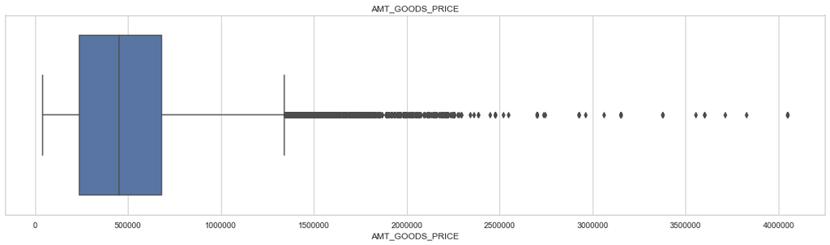

```python
# Plotting Box Plot for the below defined numeric column
plotBoxPlot(df, "AMT_GOODS_PRICE")
```

**Findings:** AMT_GOODS_PRICE is defined as: For consumer loans it is the price of the goods for which the loan is given.

We notice that it follows trends similar to AMT_CREDIT with most of the spread lying within 13 lakhs and can go up to 40 lakhs.

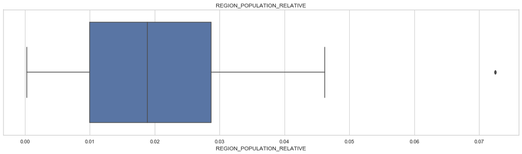

```python
# Plotting Box Plot for the below defined numeric column
plotBoxPlot(df, "REGION_POPULATION_RELATIVE")
```

**Findings:** REGION_POPULATION_RELATIVE - Normalized population of region where client lives (higher number means the client lives in more populated region)

We notice that one client lives in a highly populated region, whereas the others mostly sat in regions that have 0.01 to 0.03 (approx) normalized population density

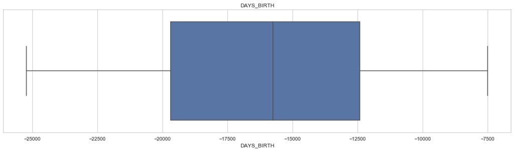

```python
# Plotting Box Plot for the below defined numeric column
plotBoxPlot(df, "DAYS_BIRTH")
```

**Findings:** Based on the above plot, we notice that majority of the client are between 34 to 54 years of age with the youngest being 20 and the oldest being around 68

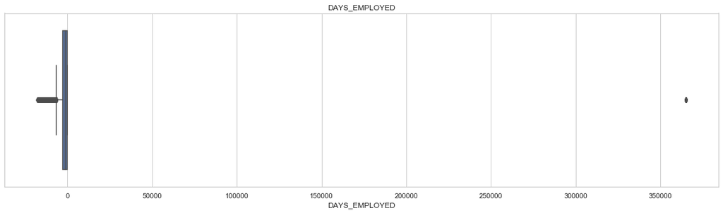

```python
# Plotting Box Plot for the below defined numeric column
plotBoxPlot(df, "DAYS_EMPLOYED")
```

**Findings:** Here, we notice that there is a definite data entry error for a client or the client has provided wrong information regarding the number of workdays. For plots like this, the spread can be analyzed better when the outlier is removed as it skews the boxplot

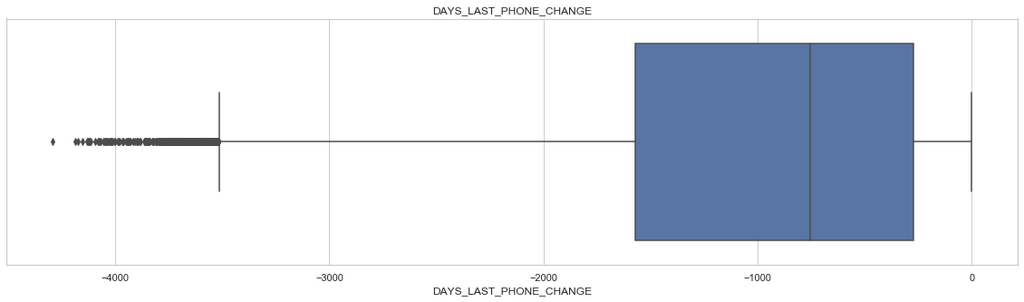

```python
# Plotting Box Plot for the below defined numeric column
plotBoxPlot(df, "DAYS_LAST_PHONE_CHANGE")
```

**Findings:** Here, we notice that most clients have been using their phones between 1 to 4 years, with some clients having used their phones for a surprising 11 years

### Binning the continous variables

We shall now perform binning on a few columns. One way to do it is by using the in-built pd.cut()/ pd.qcut() functionality by Pandas.

#### Cumulative Population Column

**Note:**

- REGION_POPULATION_RELATIVE --> Column indicating Normalized population. Post analysis from the boxplot, we shall bin the column into sparse, normal and densely populated areas that the client belongs to
- DAYS_BIRTH --> column indicating the age of the person in days

```python
#Binning the below-mentioned column into 3 categories
df['REGION_POPULATION_RELATIVE'] = pd.cut(df.REGION_POPULATION_RELATIVE,
                                          bins=[0, 0.02, 0.04, 0.08],
                                          labels=["sparse", "normal", "dense"])
```

```python
# Ensuring the function was applied correctly
df['REGION_POPULATION_RELATIVE'].head()
```

```
0    sparse
1    sparse
2    sparse
3    sparse
4    normal
Name: REGION_POPULATION_RELATIVE, dtype: category
Categories (3, object): [sparse < normal < dense]
```

#### Client Age Column

**Note:** We shall now also divide the age into the following:

- 20-30 years - young (7300 to 10950 days)
- 30-40 years - middle-aged (10950 to 14600 days)
- 40-50 years - old (14600 to 18250 days)
- 50 and above - senior (18250 to 30000)

```python
# Multiplying the number of days by -1 as the values provided are negative
df['DAYS_BIRTH'] = df['DAYS_BIRTH']*-1
df['DAYS_BIRTH'].head()
```

```
0     9461
1    16765
2    19046
3    19005
4    19932
Name: DAYS_BIRTH, dtype: int64
```

```python
#Binning the below-mentioned column into 4 categories
df['DAYS_BIRTH'] = pd.cut(df.DAYS_BIRTH,
                          bins=[7300, 10950, 14600, 18250, 30000],
                          labels=["young", "middle-aged", "old", "senior"])
```

```python
# Ensuring the function was applied correctly
df['DAYS_BIRTH'].head()
```

```
0     young
1       old
2    senior
3    senior
4    senior
Name: DAYS_BIRTH, dtype: category
Categories (4, object): [young < middle-aged < old < senior]
```

### Checking the data imbalance

We shall now check the data imbalance of the target variable.

For the **TARGET** variable, following are the interpretations:

- 1 - client with payment difficulties: he/she had late payment more than X days on at least one of the first Y installments of the loan in our sample
- 0 - all other cases

```python
# Checking the frequency and type of 0s and 1a
imbalance = df['TARGET'].value_counts()
imbalance
```

```
0    282686
1     24825
Name: TARGET, dtype: int64
```

```python
# Getting the total number of 0s and 1s
total = imbalance[0] + imbalance[1]
total
```

```
307511
```

```python
# Checking the % of 0s
round((imbalance[0]/total)*100,2)
```

```
91.93
```

```python
# Checking the % of 1s
round((imbalance[1]/total)*100,2)
```

```
8.07
```

Hence, we see that the data definitely has a data imbalance issue that needs to be dealt with.

- **0** - 91.93%
- **1** - 8.07%

### Subsetting the data

On the basis of the target variable, we shall now subset the data.

```python
# Subsetting the data where target = 1
dfOne = df[df['TARGET'] > 0]
```

```python
# Doing a sense check of the data
dfOne.shape
```

```
(24825, 65)
```

```python
# Viewing the data
dfOne.head()
```

|  | SK_ID_CURR | TARGET | NAME_CONTRACT_TYPE | CODE_GENDER | FLAG_OWN_CAR | FLAG_OWN_REALTY | CNT_CHILDREN | AMT_INCOME_TOTAL | AMT_CREDIT | AMT_ANNUITY | AMT_GOODS_PRICE | NAME_TYPE_SUITE | NAME_INCOME_TYPE | NAME_EDUCATION_TYPE | NAME_FAMILY_STATUS | NAME_HOUSING_TYPE | REGION_POPULATION_RELATIVE | DAYS_BIRTH | DAYS_EMPLOYED | DAYS_REGISTRATION | DAYS_ID_PUBLISH | FLAG_MOBIL | FLAG_EMP_PHONE | FLAG_WORK_PHONE | FLAG_CONT_MOBILE | FLAG_PHONE | FLAG_EMAIL | CNT_FAM_MEMBERS | REGION_RATING_CLIENT | … |
| --- | --- | --- | --- | --- | --- | --- | --- | --- | --- | --- | --- | --- | --- | --- | --- | --- | --- | --- | --- | --- | --- | --- | --- | --- | --- | --- | --- | --- | --- | --- |
| 0 | 100002 | 1 | Cash loans | M | N | Y | 0 | 202500.0 | 406597.5 | 24700.5 | 351000.0 | Unaccompanied | Working | Secondary / secondary special | Single / not married | House / apartment | sparse | young | -637 | -3648.0 | -2120 | 1 | 1 | 0 | 1 | 1 | 0 | 1.0 | 2 | … |
| 26 | 100031 | 1 | Cash loans | F | N | Y | 0 | 112500.0 | 979992.0 | 27076.5 | 702000.0 | Unaccompanied | Working | Secondary / secondary special | Widow | House / apartment | sparse | senior | -2628 | -6573.0 | -1827 | 1 | 1 | 0 | 1 | 0 | 0 | 1.0 | 3 | … |
| 40 | 100047 | 1 | Cash loans | M | N | Y | 0 | 202500.0 | 1193580.0 | 35028.0 | 855000.0 | Unaccompanied | Commercial associate | Secondary / secondary special | Married | House / apartment | normal | old | -1262 | -1182.0 | -1029 | 1 | 1 | 0 | 1 | 0 | 0 | 2.0 | 2 | … |
| 42 | 100049 | 1 | Cash loans | F | N | N | 0 | 135000.0 | 288873.0 | 16258.5 | 238500.0 | Unaccompanied | Working | Secondary / secondary special | Civil marriage | House / apartment | sparse | middle-aged | -3597 | -45.0 | -4409 | 1 | 1 | 1 | 1 | 1 | 0 | 2.0 | 3 | … |
| 81 | 100096 | 1 | Cash loans | F | N | Y | 0 | 81000.0 | 252000.0 | 14593.5 | 252000.0 | Unaccompanied | Pensioner | Secondary / secondary special | Married | House / apartment | normal | senior | 365243 | -5391.0 | -4199 | 1 | 0 | 0 | 1 | 0 | 0 | 2.0 | 2 | … |

```python
# Subsetting the data where target = 0
dfZero = df[df['TARGET'] < 1]
```

```python
# Doing a sense check of the data
dfZero.shape
```

```
(282686, 65)
```

```python
# Viewing the data
dfZero.head()
```

|  | SK_ID_CURR | TARGET | NAME_CONTRACT_TYPE | CODE_GENDER | FLAG_OWN_CAR | FLAG_OWN_REALTY | CNT_CHILDREN | AMT_INCOME_TOTAL | AMT_CREDIT | AMT_ANNUITY | AMT_GOODS_PRICE | NAME_TYPE_SUITE | NAME_INCOME_TYPE | NAME_EDUCATION_TYPE | NAME_FAMILY_STATUS | NAME_HOUSING_TYPE | REGION_POPULATION_RELATIVE | DAYS_BIRTH | DAYS_EMPLOYED | DAYS_REGISTRATION | DAYS_ID_PUBLISH | FLAG_MOBIL | FLAG_EMP_PHONE | FLAG_WORK_PHONE | FLAG_CONT_MOBILE | FLAG_PHONE | FLAG_EMAIL | CNT_FAM_MEMBERS | REGION_RATING_CLIENT | … |
| --- | --- | --- | --- | --- | --- | --- | --- | --- | --- | --- | --- | --- | --- | --- | --- | --- | --- | --- | --- | --- | --- | --- | --- | --- | --- | --- | --- | --- | --- | --- |
| 1 | 100003 | 0 | Cash loans | F | N | N | 0 | 270000.0 | 1293502.5 | 35698.5 | 1129500.0 | Family | State servant | Higher education | Married | House / apartment | sparse | old | -1188 | -1186.0 | -291 | 1 | 1 | 0 | 1 | 1 | 0 | 2.0 | 1 | … |
| 2 | 100004 | 0 | Revolving loans | M | Y | Y | 0 | 67500.0 | 135000.0 | 6750.0 | 135000.0 | Unaccompanied | Working | Secondary / secondary special | Single / not married | House / apartment | sparse | senior | -225 | -4260.0 | -2531 | 1 | 1 | 1 | 1 | 1 | 0 | 1.0 | 2 | … |
| 3 | 100006 | 0 | Cash loans | F | N | Y | 0 | 135000.0 | 312682.5 | 29686.5 | 297000.0 | Unaccompanied | Working | Secondary / secondary special | Civil marriage | House / apartment | sparse | senior | -3039 | -9833.0 | -2437 | 1 | 1 | 0 | 1 | 0 | 0 | 2.0 | 2 | … |
| 4 | 100007 | 0 | Cash loans | M | N | Y | 0 | 121500.0 | 513000.0 | 21865.5 | 513000.0 | Unaccompanied | Working | Secondary / secondary special | Single / not married | House / apartment | normal | senior | -3038 | -4311.0 | -3458 | 1 | 1 | 0 | 1 | 0 | 0 | 1.0 | 2 | … |
| 5 | 100008 | 0 | Cash loans | M | N | Y | 0 | 99000.0 | 490495.5 | 27517.5 | 454500.0 | Spouse, partner | State servant | Secondary / secondary special | Married | House / apartment | normal | old | -1588 | -4970.0 | -477 | 1 | 1 | 1 | 1 | 1 | 0 | 2.0 | 2 | … |

### Correlation between different variables

```python
# Selecting only the numeric columns to perform correlation analysis
numerics = ['int16', 'int32', 'int64', 'float16', 'float32', 'float64']
df_num = df.select_dtypes(include=numerics)
```

```python
df_num.head()
```

|  | SK_ID_CURR | TARGET | CNT_CHILDREN | AMT_INCOME_TOTAL | AMT_CREDIT | AMT_ANNUITY | AMT_GOODS_PRICE | DAYS_EMPLOYED | DAYS_REGISTRATION | DAYS_ID_PUBLISH | FLAG_MOBIL | FLAG_EMP_PHONE | FLAG_WORK_PHONE | FLAG_CONT_MOBILE | FLAG_PHONE | FLAG_EMAIL | CNT_FAM_MEMBERS | REGION_RATING_CLIENT | REGION_RATING_CLIENT_W_CITY | HOUR_APPR_PROCESS_START | REG_REGION_NOT_LIVE_REGION | REG_REGION_NOT_WORK_REGION | LIVE_REGION_NOT_WORK_REGION | REG_CITY_NOT_LIVE_CITY | REG_CITY_NOT_WORK_CITY | LIVE_CITY_NOT_WORK_CITY | EXT_SOURCE_2 | OBS_30_CNT_SOCIAL_CIRCLE | DEF_30_CNT_SOCIAL_CIRCLE | … |
| --- | --- | --- | --- | --- | --- | --- | --- | --- | --- | --- | --- | --- | --- | --- | --- | --- | --- | --- | --- | --- | --- | --- | --- | --- | --- | --- | --- | --- | --- | --- |
| 0 | 100002 | 1 | 0 | 202500.0 | 406597.5 | 24700.5 | 351000.0 | -637 | -3648.0 | -2120 | 1 | 1 | 0 | 1 | 1 | 0 | 1.0 | 2 | 2 | 10 | 0 | 0 | 0 | 0 | 0 | 0 | 0.262949 | 2.0 | 2.0 | … |
| 1 | 100003 | 0 | 0 | 270000.0 | 1293502.5 | 35698.5 | 1129500.0 | -1188 | -1186.0 | -291 | 1 | 1 | 0 | 1 | 1 | 0 | 2.0 | 1 | 1 | 11 | 0 | 0 | 0 | 0 | 0 | 0 | 0.622246 | 1.0 | 0.0 | … |
| 2 | 100004 | 0 | 0 | 67500.0 | 135000.0 | 6750.0 | 135000.0 | -225 | -4260.0 | -2531 | 1 | 1 | 1 | 1 | 1 | 0 | 1.0 | 2 | 2 | 9 | 0 | 0 | 0 | 0 | 0 | 0 | 0.555912 | 0.0 | 0.0 | … |
| 3 | 100006 | 0 | 0 | 135000.0 | 312682.5 | 29686.5 | 297000.0 | -3039 | -9833.0 | -2437 | 1 | 1 | 0 | 1 | 0 | 0 | 2.0 | 2 | 2 | 17 | 0 | 0 | 0 | 0 | 0 | 0 | 0.650442 | 2.0 | 0.0 | … |
| 4 | 100007 | 0 | 0 | 121500.0 | 513000.0 | 21865.5 | 513000.0 | -3038 | -4311.0 | -3458 | 1 | 1 | 0 | 1 | 0 | 0 | 1.0 | 2 | 2 | 11 | 0 | 0 | 0 | 0 | 1 | 1 | 0.322738 | 0.0 | 0.0 | … |

```python
# Imputing the numeric values with median values
df_num.fillna(df_num.median(), inplace=True)
```

```python
# Plotting the correlation matrix of the data
cor = df_num.corr()
```

```python
#Correlation with output variable
cor_target = abs(cor['TARGET'])
```

```python
#Selecting highly correlated features
relevant_features = cor_target[cor_target>0.1]
relevant_features
```

```
TARGET          1.000000
EXT_SOURCE_2    0.160295
Name: TARGET, dtype: float64
```

## Why correlation cannot be taken as a metric for binary predictors

We have now done correlation analysis on the entire table. We notice that for binary predictors, correlation is not an optimal method to find the most predicted variables.

- We observe from the result that we have 1 correlation with EXT_SOURCE_2, besides which all of the variables show no correlations
- A correlation above 0.5 or below -0.5 would be considered significant. Here, we notice that there is **no** strong independent feature that is correlated with the target variable
- If we were performing a binary classification problem, we can tackle the issue by using the Variable Importance Feature in Random Forest or XGBoost

##### Pearson correlation is used for continuous data, Thus, when applied on binary data (TARGET), we obtain relationshops that are not precise or necessarily correct

### Univariate Analysis on data where 'TARGET' = 1

Here, we are doing univariate analysis for dfOne and dfZero separately. We shall do this for numerical as well as categorical variables.

#### Univariate Analysis for numerical variables

```python
# Sense check of data
dfOne.head()
```

|  | SK_ID_CURR | TARGET | NAME_CONTRACT_TYPE | CODE_GENDER | FLAG_OWN_CAR | FLAG_OWN_REALTY | CNT_CHILDREN | AMT_INCOME_TOTAL | AMT_CREDIT | AMT_ANNUITY | AMT_GOODS_PRICE | NAME_TYPE_SUITE | NAME_INCOME_TYPE | NAME_EDUCATION_TYPE | NAME_FAMILY_STATUS | NAME_HOUSING_TYPE | REGION_POPULATION_RELATIVE | DAYS_BIRTH | DAYS_EMPLOYED | DAYS_REGISTRATION | DAYS_ID_PUBLISH | FLAG_MOBIL | FLAG_EMP_PHONE | FLAG_WORK_PHONE | FLAG_CONT_MOBILE | FLAG_PHONE | FLAG_EMAIL | CNT_FAM_MEMBERS | REGION_RATING_CLIENT | … |
| --- | --- | --- | --- | --- | --- | --- | --- | --- | --- | --- | --- | --- | --- | --- | --- | --- | --- | --- | --- | --- | --- | --- | --- | --- | --- | --- | --- | --- | --- | --- |
| 0 | 100002 | 1 | Cash loans | M | N | Y | 0 | 202500.0 | 406597.5 | 24700.5 | 351000.0 | Unaccompanied | Working | Secondary / secondary special | Single / not married | House / apartment | sparse | young | -637 | -3648.0 | -2120 | 1 | 1 | 0 | 1 | 1 | 0 | 1.0 | 2 | … |
| 26 | 100031 | 1 | Cash loans | F | N | Y | 0 | 112500.0 | 979992.0 | 27076.5 | 702000.0 | Unaccompanied | Working | Secondary / secondary special | Widow | House / apartment | sparse | senior | -2628 | -6573.0 | -1827 | 1 | 1 | 0 | 1 | 0 | 0 | 1.0 | 3 | … |
| 40 | 100047 | 1 | Cash loans | M | N | Y | 0 | 202500.0 | 1193580.0 | 35028.0 | 855000.0 | Unaccompanied | Commercial associate | Secondary / secondary special | Married | House / apartment | normal | old | -1262 | -1182.0 | -1029 | 1 | 1 | 0 | 1 | 0 | 0 | 2.0 | 2 | … |
| 42 | 100049 | 1 | Cash loans | F | N | N | 0 | 135000.0 | 288873.0 | 16258.5 | 238500.0 | Unaccompanied | Working | Secondary / secondary special | Civil marriage | House / apartment | sparse | middle-aged | -3597 | -45.0 | -4409 | 1 | 1 | 1 | 1 | 1 | 0 | 2.0 | 3 | … |
| 81 | 100096 | 1 | Cash loans | F | N | Y | 0 | 81000.0 | 252000.0 | 14593.5 | 252000.0 | Unaccompanied | Pensioner | Secondary / secondary special | Married | House / apartment | normal | senior | 365243 | -5391.0 | -4199 | 1 | 0 | 0 | 1 | 0 | 0 | 2.0 | 2 | … |

```python
# Subsetting the numerical columns from dfOne
numerics = ['int16', 'int32', 'int64', 'float16', 'float32', 'float64']
dfOne_num = dfOne.select_dtypes(include=numerics)
```

```python
# Imputing the numeric values with median values
dfOne_num.fillna(dfOne_num.median(), inplace=True)
```

```python
# TO understand the proper spread of the data, we add filters to remove the skew
dfOne_num = dfOne_num[dfOne_num['DAYS_EMPLOYED'] < 300000]
dfOne_num = dfOne_num[dfOne_num['AMT_INCOME_TOTAL'] < 1000000]
```

```python
# Function to plot histogram for numerical, univariate analysis
def plotHistogram(df, colName):
    '''
    This function is used to set the style of the plot, name the graph and plot the distribution for the specified column

    Inputs:
    @df (dataframe) - The dataframe for which histograms are to be plotted
    @colName (string) - The numeric column for which histograms is to be plotted

    Output:
    Titles distribution plot of specified colName
    '''
    sns.set(style="whitegrid")
    plt.figure(figsize=(20,5))
    plt.title(colName)
    plt.ylabel('Density', fontsize=14)
    sns.distplot(df[colName], kde=True)#, fit=stats.gamma)
```

**Note:** Here the y-axis represents the frequency density for each of the bins such that the area under the curve is equal to 1.

#### Analysis of Client Income

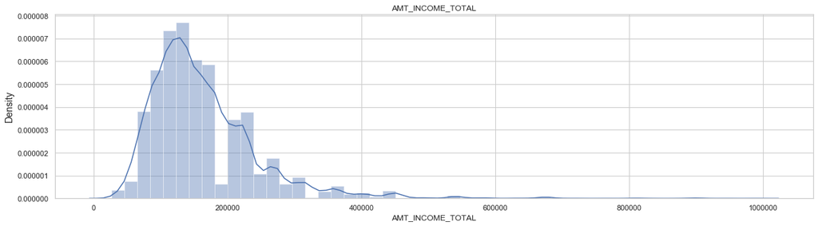

```python
plotHistogram(dfOne_num, 'AMT_INCOME_TOTAL')
```

**Findings:** Here we can observe that the highest frequency of income amount for clients is between Rs. 100000 and Rs. 200000

#### Analysis of Days of Employment of the client

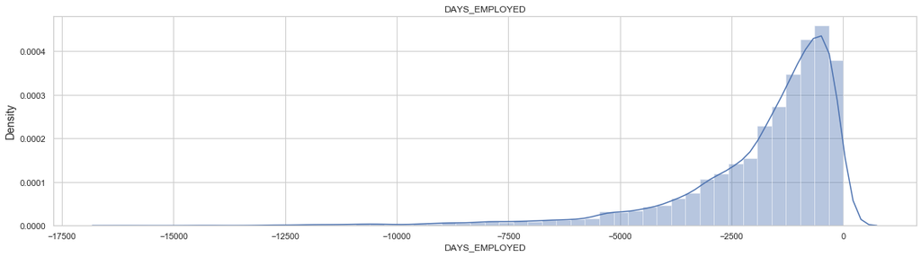

```python
plotHistogram(dfOne_num, 'DAYS_EMPLOYED')
```

**Findings:** Here we can observe that the highest frequency of days that the clients have been employed is between 625 and 937 days i.e between 1.7 and 2.5 years

#### Analysis of Credit Amount of Loan

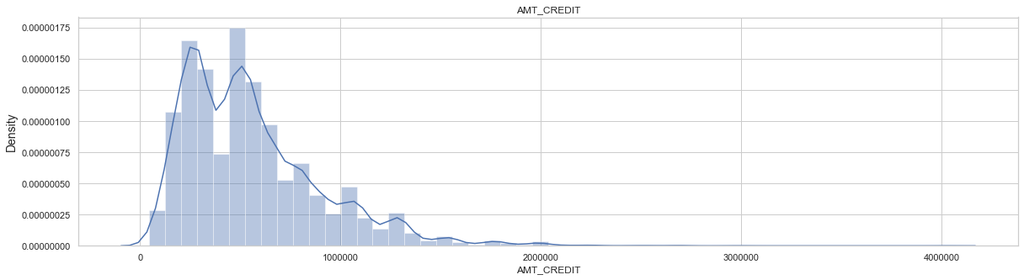

```python
plotHistogram(dfOne_num, 'AMT_CREDIT')
```

**Findings:** Here we can observe that the highest frequency density of credit is approximately Rs 500000 - Rs 600000

#### Analysis of Price of Loan Goods

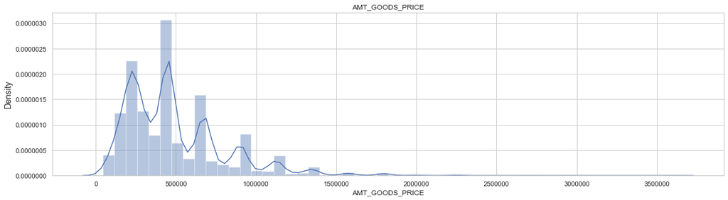

```python
plotHistogram(dfOne_num, 'AMT_GOODS_PRICE')
```

**Findings:** Here we can observe that the highest frequency density of price of the goods is approximately Rs 4,70,000

#### Analysis of Loan Annuity

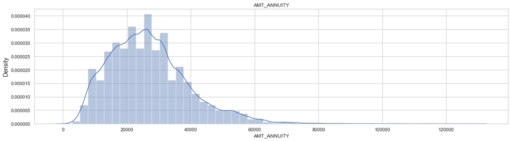

```python
plotHistogram(dfOne_num, 'AMT_ANNUITY')
```

**Findings:** Here we can observe that there is relatively even distribution of loan annuity for the clients with approx Rs 28000- Rs 30000 having the highest density

#### Univariate Analysis for categorical variables

```python
## Subsetting data for finding categorical variables
dfOne_cat = dfOne.select_dtypes(include='object')
```

```python
# Imputing the categorical values with mode
dfOne_cat.fillna(dfOne_cat.mode(), inplace=True)
```

```python
# Defining a function to view the distribution of the categorical variables
def plotFrequencyTable(df, catColName):
    '''
    This function is used to plot the frequency table of the specified categorical variable
    @df (dataframe) - Dataframe for which frequency table is to be plotted
    @catColName (string) - Column name for which frequency table is to be plotted
    '''
    sns.countplot(x=catColName, data=df)
    plt.title(catColName)
    plt.xticks(rotation = 90)
    plt.show();
```

#### Analysis of Client Income Type

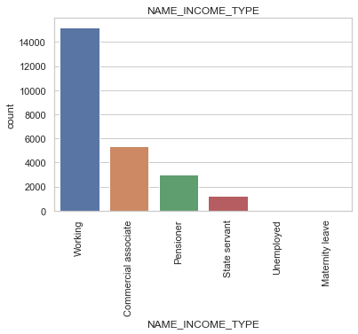

```python
plotFrequencyTable(dfOne_cat,'NAME_INCOME_TYPE')
```

**Findings:** Here we can observe that most of the clients are working followed by Commercial associates

#### Analysis of Client Education Level

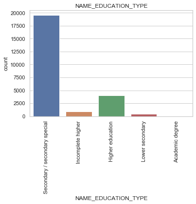

```python
plotFrequencyTable(dfOne_cat,'NAME_EDUCATION_TYPE')
```

**Findings:** Here we can observe that most of the clients completed Secondary / Secondary special followed by Higher Education

#### Analysis of Client Housing Type

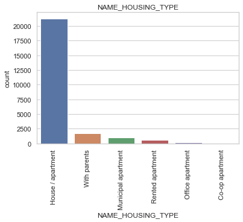

```python
plotFrequencyTable(dfOne_cat,'NAME_HOUSING_TYPE')
```

**Findings:** Here we can observe that most of the clients stay in House/Apartments of their own followed by that of clients living with their parents

#### Analysis of Client Family Status

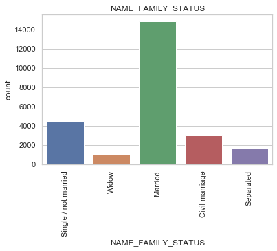

```python
plotFrequencyTable(dfOne_cat,'NAME_FAMILY_STATUS')
```

**Findings:** Here we can observe that most of the clients are married followed by single/not married status

#### Analysis of Client Accompaniment status

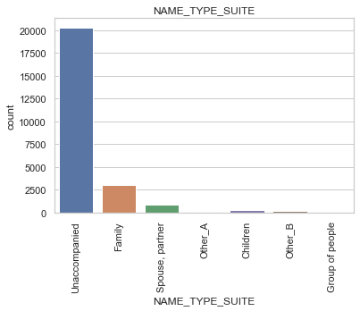

```python
plotFrequencyTable(dfOne_cat,'NAME_TYPE_SUITE')
```

**Findings:** Here we can observe that most of the clients are unaccompanied when applying for loan followed by accompaniment by family

### Univariate Analysis where 'TARGET' = 0

**Note:** We shall do this for 5 numerical and 5 categorical variables.

#### Univariate Analysis for numerical variables

```python
# Sense check of data
dfZero.head()
```

|  | SK_ID_CURR | TARGET | NAME_CONTRACT_TYPE | CODE_GENDER | FLAG_OWN_CAR | FLAG_OWN_REALTY | CNT_CHILDREN | AMT_INCOME_TOTAL | AMT_CREDIT | AMT_ANNUITY | AMT_GOODS_PRICE | NAME_TYPE_SUITE | NAME_INCOME_TYPE | NAME_EDUCATION_TYPE | NAME_FAMILY_STATUS | NAME_HOUSING_TYPE | REGION_POPULATION_RELATIVE | DAYS_BIRTH | DAYS_EMPLOYED | DAYS_REGISTRATION | DAYS_ID_PUBLISH | FLAG_MOBIL | FLAG_EMP_PHONE | FLAG_WORK_PHONE | FLAG_CONT_MOBILE | FLAG_PHONE | FLAG_EMAIL | CNT_FAM_MEMBERS | REGION_RATING_CLIENT | … |
| --- | --- | --- | --- | --- | --- | --- | --- | --- | --- | --- | --- | --- | --- | --- | --- | --- | --- | --- | --- | --- | --- | --- | --- | --- | --- | --- | --- | --- | --- | --- |
| 1 | 100003 | 0 | Cash loans | F | N | N | 0 | 270000.0 | 1293502.5 | 35698.5 | 1129500.0 | Family | State servant | Higher education | Married | House / apartment | sparse | old | -1188 | -1186.0 | -291 | 1 | 1 | 0 | 1 | 1 | 0 | 2.0 | 1 | … |
| 2 | 100004 | 0 | Revolving loans | M | Y | Y | 0 | 67500.0 | 135000.0 | 6750.0 | 135000.0 | Unaccompanied | Working | Secondary / secondary special | Single / not married | House / apartment | sparse | senior | -225 | -4260.0 | -2531 | 1 | 1 | 1 | 1 | 1 | 0 | 1.0 | 2 | … |
| 3 | 100006 | 0 | Cash loans | F | N | Y | 0 | 135000.0 | 312682.5 | 29686.5 | 297000.0 | Unaccompanied | Working | Secondary / secondary special | Civil marriage | House / apartment | sparse | senior | -3039 | -9833.0 | -2437 | 1 | 1 | 0 | 1 | 0 | 0 | 2.0 | 2 | … |
| 4 | 100007 | 0 | Cash loans | M | N | Y | 0 | 121500.0 | 513000.0 | 21865.5 | 513000.0 | Unaccompanied | Working | Secondary / secondary special | Single / not married | House / apartment | normal | senior | -3038 | -4311.0 | -3458 | 1 | 1 | 0 | 1 | 0 | 0 | 1.0 | 2 | … |
| 5 | 100008 | 0 | Cash loans | M | N | Y | 0 | 99000.0 | 490495.5 | 27517.5 | 454500.0 | Spouse, partner | State servant | Secondary / secondary special | Married | House / apartment | normal | old | -1588 | -4970.0 | -477 | 1 | 1 | 1 | 1 | 1 | 0 | 2.0 | 2 | … |

```python
# Subsetting the numerical columns from dfOne
numerics = ['int16', 'int32', 'int64', 'float16', 'float32', 'float64']
dfZero_num = dfZero.select_dtypes(include=numerics)
```

```python
# Imputing the numeric values with median values
dfZero_num.fillna(dfZero_num.median(), inplace=True)
```

```python
# TO understand the proper spread of the data, we add filters to remove the skew
dfZero_num = dfZero_num[dfZero_num['DAYS_EMPLOYED'] < 300000]
dfZero_num = dfZero_num[dfZero_num['AMT_INCOME_TOTAL'] < 1000000]
```

#### Analysis of Client Income

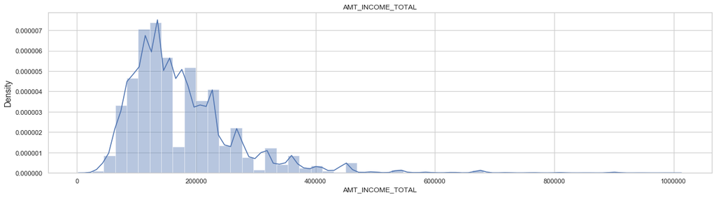

```python
plotHistogram(dfZero_num, 'AMT_INCOME_TOTAL')
```

**Findings:** Here we can observe that the highest frequency of income amount for clients is between Rs. 100000 and Rs. 200000

#### Analysis of Days of Employment of the client

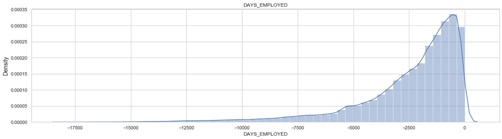

```python
plotHistogram(dfZero_num, 'DAYS_EMPLOYED')
```

**Findings:** Here we can observe that the highest frequency of days that the clients have been employed is between 715 and 1040 days i.e between 1.9 and 2.8 years

#### Analysis of Credit Amount of Loan

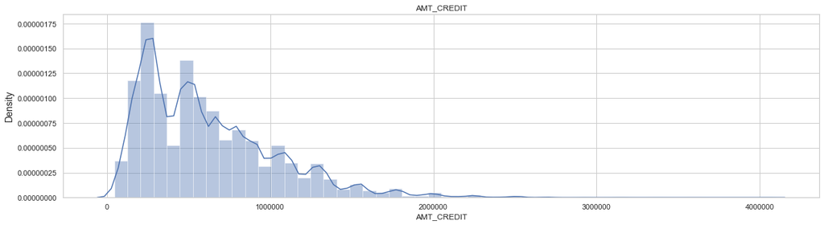

```python
plotHistogram(dfZero_num, 'AMT_CREDIT')
```

**Findings:** Here we can observe that the highest frequency density of credit is approximately Rs 200000 - Rs 350000

#### Analysis of Price of Loan Goods

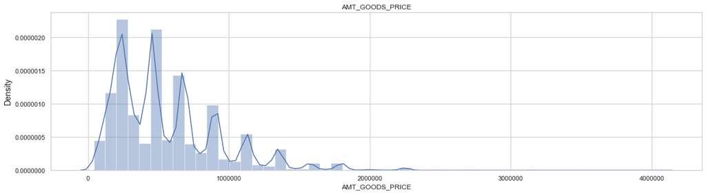

```python
plotHistogram(dfZero_num, 'AMT_GOODS_PRICE')
```

#### Analysis of Loan Annuity

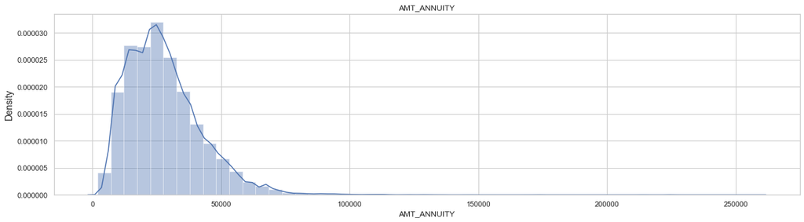

```python
plotHistogram(dfZero_num, 'AMT_ANNUITY')
```

#### Univariate Analysis for categorical variables

```python
## Subsetting data for finding categorical variables
dfZero_cat = dfZero.select_dtypes(include='object')
```

```python
# Imputing the categorical values with mode
dfZero_cat.fillna(dfZero_cat.mode(), inplace=True)
```

#### Analysis of Client Income Type

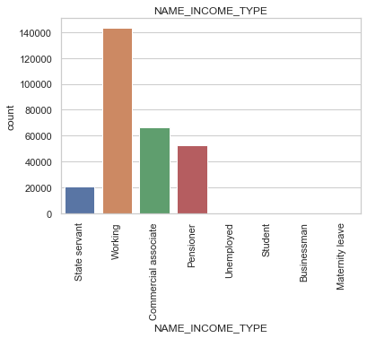

```python
plotFrequencyTable(dfZero_cat,'NAME_INCOME_TYPE')
```

**Findings:** Here we can observe that most of the clients are working followed by Commercial associates and Pensioners

#### Analysis of Client Education Level

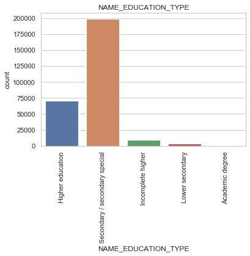

```python
plotFrequencyTable(dfZero_cat,'NAME_EDUCATION_TYPE')
```

**Findings:** Here we can observe that most of the clients completed Secondary / Secondary special followed by Higher Education

#### Analysis of Client Housing Type

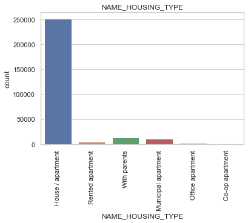

```python
plotFrequencyTable(dfZero_cat,'NAME_HOUSING_TYPE')
```

**Findings:** Here we can observe that most of the clients stay in House/Apartments of their own followed by that of clients living with their parents and Municipal Apartments

#### Analysis of Client Family Status

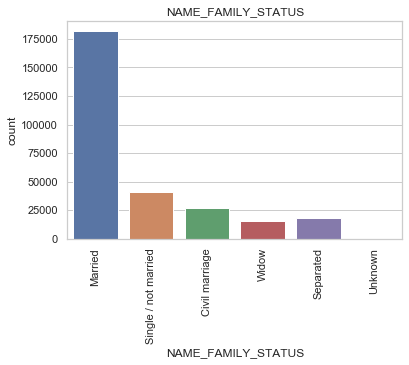

```python
plotFrequencyTable(dfZero_cat,'NAME_FAMILY_STATUS')
```

**Findings:** Here we can observe that most of the clients are married followed by single/not married status

#### Analysis of Client Accompaniment status

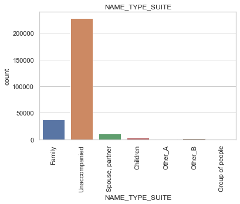

```python
plotFrequencyTable(dfZero_cat,'NAME_TYPE_SUITE')
```

**Findings:** Here we can observe that most of the clients are unaccompanied when applying for loan followed by accompaniment by family